# Module 7: Data Analysis and Experimental Design

MB 360: Scientific Inquiry in Microbiology At the Bench

Carlos C. Goller, Ph.D.

NC State University | Department of Biological Sciences

Camila Loyola, Graduate Teaching Assistant

2026-09-08

## Module 7: Data Analysis and Experimental Design

MB 360: Scientific Inquiry in Microbiology At the Bench

MB 360 Lab Workbook  
NC State University | Department of Biological Sciences

## Overview

**Weeks 13–14** · Genome assembly · Annotation review · Comparative analysis · Phenotype connection

- Submit an assembly job to BV-BRC
- Apply bioinformatics tools to assemble and annotate genomes
- Connect genomic results back to phenotypic evidence

## Learning Outcomes

- **Explain** the purpose of bioinformatics tools and workflows used
- **Discuss** the significance of genome assembly
- **Practice** using web-based bioinformatics tools
- **Explore** genome assemblies and annotations
- **Collect** and **interpret** genomic data in the context of phenotypic analyses
- **Revise** the draft for the individual and group projects

## Skills & Knowledge

Skills

- Perform sequence-read quality review
- Assemble microbial genomes
- Annotate and explore genome content

Knowledge

- Steps required to assemble a microbial genome
- Tools for filtering, assembly, annotation, and metabolic modelling
- Cloud-based bioinformatics workflow submission

## Background

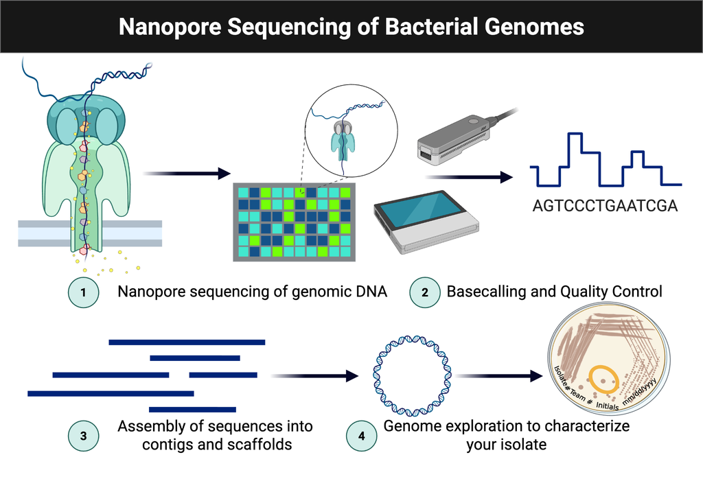

Sequencing-analysis pipeline for genome assembly and comparative interpretation.

Compare your isolate to *Delftia acidovorans* SPH-1 and related public genomes to identify genetic features that explain observed growth and metabolic behaviour.

## Lab Safety

This is a **bioinformatics lab** — no live organisms or chemicals are used today.

## Methods: Genome Assembly (BV-BRC)

1. Access the shared BV-BRC workspace
2. Obtain the concatenated read files for your isolate
3. Run the **Comprehensive Genome Analysis** workflow  
   (long-read + paired short-read data)
4. Create an output folder labelled with the isolate name
5. Submit the job and monitor the results
6. Upload the assembled FASTA file to **SeqHub**

## Methods: Genome Comparisons

- Use **Similar Genome Finder** in BV-BRC
- Compare your isolate against representative and public genomes
- Save result tables and pie-chart images